# Risk Factor Analysis

## Outcome Variable

**Outcome Variable:** stunted

## Predictor Variables

**Intervention Variable:** parity

**Adjustment Set:**

- arm
- W_mage
- meducyrs
- feducyrs
- hhwealth_quart
- hfoodsec
- W_mhtcm
- vagbrth
- W_nrooms
- impfloor
- impsan
- safeh20
- delta_W_mage
- delta_meducyrs
- delta_feducyrs
- delta_hhwealth_quart
- delta_hfoodsec
- delta_W_mhtcm
- delta_vagbrth
- delta_W_nrooms
- delta_impfloor
- delta_impsan
- delta_safeh20

## Stratifying Variables

The analysis was stratified on these variable(s):

- agecat
- studyid
- country

## Data Summary

| agecat | studyid | country | parity | stunted | n_cell | n |
| --- | --- | --- | --- | --- | --- | --- |
| Birth | ki1000304b-SAS-CompFeed | INDIA | 1 | 0 | 34 | 187 |
| Birth | ki1000304b-SAS-CompFeed | INDIA | 1 | 1 | 13 | 187 |
| Birth | ki1000304b-SAS-CompFeed | INDIA | 2 | 0 | 37 | 187 |
| Birth | ki1000304b-SAS-CompFeed | INDIA | 2 | 1 | 16 | 187 |
| Birth | ki1000304b-SAS-CompFeed | INDIA | 3+ | 0 | 70 | 187 |
| Birth | ki1000304b-SAS-CompFeed | INDIA | 3+ | 1 | 17 | 187 |
| Birth | ki1101329-Keneba | GAMBIA | 1 | 0 | 140 | 1407 |
| Birth | ki1101329-Keneba | GAMBIA | 1 | 1 | 16 | 1407 |
| Birth | ki1101329-Keneba | GAMBIA | 2 | 0 | 138 | 1407 |
| Birth | ki1101329-Keneba | GAMBIA | 2 | 1 | 8 | 1407 |
| Birth | ki1101329-Keneba | GAMBIA | 3+ | 0 | 1054 | 1407 |
| Birth | ki1101329-Keneba | GAMBIA | 3+ | 1 | 51 | 1407 |
| Birth | ki1126311-ZVITAMBO | ZIMBABWE | 1 | 0 | 5332 | 13829 |
| Birth | ki1126311-ZVITAMBO | ZIMBABWE | 1 | 1 | 640 | 13829 |
| Birth | ki1126311-ZVITAMBO | ZIMBABWE | 2 | 0 | 3718 | 13829 |
| Birth | ki1126311-ZVITAMBO | ZIMBABWE | 2 | 1 | 407 | 13829 |
| Birth | ki1126311-ZVITAMBO | ZIMBABWE | 3+ | 0 | 3347 | 13829 |
| Birth | ki1126311-ZVITAMBO | ZIMBABWE | 3+ | 1 | 385 | 13829 |
| Birth | ki1135781-COHORTS | GUATEMALA | 1 | 0 | 103 | 852 |
| Birth | ki1135781-COHORTS | GUATEMALA | 1 | 1 | 9 | 852 |
| Birth | ki1135781-COHORTS | GUATEMALA | 2 | 0 | 124 | 852 |
| Birth | ki1135781-COHORTS | GUATEMALA | 2 | 1 | 13 | 852 |
| Birth | ki1135781-COHORTS | GUATEMALA | 3+ | 0 | 575 | 852 |
| Birth | ki1135781-COHORTS | GUATEMALA | 3+ | 1 | 28 | 852 |
| Birth | ki1135781-COHORTS | INDIA | 1 | 0 | 582 | 4122 |
| Birth | ki1135781-COHORTS | INDIA | 1 | 1 | 114 | 4122 |
| Birth | ki1135781-COHORTS | INDIA | 2 | 0 | 939 | 4122 |
| Birth | ki1135781-COHORTS | INDIA | 2 | 1 | 98 | 4122 |
| Birth | ki1135781-COHORTS | INDIA | 3+ | 0 | 2126 | 4122 |
| Birth | ki1135781-COHORTS | INDIA | 3+ | 1 | 263 | 4122 |

[output cut: 132 more lines]

The following strata were considered:

- agecat: 24 months, studyid: ki1017093b-PROVIDE, country: BANGLADESH
- agecat: 24 months, studyid: ki1066203-TanzaniaChild2, country: TANZANIA, UNITED REPUBLIC OF
- agecat: 24 months, studyid: ki1101329-Keneba, country: GAMBIA
- agecat: 24 months, studyid: ki1113344-GMS-Nepal, country: NEPAL
- agecat: 24 months, studyid: ki1126311-ZVITAMBO, country: ZIMBABWE
- agecat: 24 months, studyid: ki1135781-COHORTS, country: GUATEMALA
- agecat: 24 months, studyid: ki1135781-COHORTS, country: INDIA
- agecat: 24 months, studyid: ki1135781-COHORTS, country: PHILIPPINES
- agecat: 24 months, studyid: kiGH5241-JiVitA-3, country: BANGLADESH
- agecat: 6 months, studyid: ki1000304b-SAS-CompFeed, country: INDIA
- agecat: 6 months, studyid: ki1000304b-SAS-FoodSuppl, country: INDIA
- agecat: 6 months, studyid: ki1017093b-PROVIDE, country: BANGLADESH
- agecat: 6 months, studyid: ki1066203-TanzaniaChild2, country: TANZANIA, UNITED REPUBLIC OF
- agecat: 6 months, studyid: ki1101329-Keneba, country: GAMBIA
- agecat: 6 months, studyid: ki1113344-GMS-Nepal, country: NEPAL
- agecat: 6 months, studyid: ki1126311-ZVITAMBO, country: ZIMBABWE
- agecat: 6 months, studyid: ki1135781-COHORTS, country: GUATEMALA
- agecat: 6 months, studyid: ki1135781-COHORTS, country: INDIA
- agecat: 6 months, studyid: ki1135781-COHORTS, country: PHILIPPINES
- agecat: 6 months, studyid: kiGH5241-JiVitA-3, country: BANGLADESH
- agecat: Birth, studyid: ki1000304b-SAS-CompFeed, country: INDIA
- agecat: Birth, studyid: ki1101329-Keneba, country: GAMBIA
- agecat: Birth, studyid: ki1126311-ZVITAMBO, country: ZIMBABWE
- agecat: Birth, studyid: ki1135781-COHORTS, country: GUATEMALA
- agecat: Birth, studyid: ki1135781-COHORTS, country: INDIA
- agecat: Birth, studyid: ki1135781-COHORTS, country: PHILIPPINES
- agecat: Birth, studyid: kiGH5241-JiVitA-3, country: BANGLADESH

### Dropped Strata

Some strata were dropped due to rare outcomes:

- agecat: 24 months, studyid: ki1066203-TanzaniaChild2, country: TANZANIA, UNITED REPUBLIC OF

## Methods Detail

We’re interested in the causal parameters $E[Y_a]$ for all values of $a \in \mathcal{A}$. These parameters represent the mean outcome if, possibly contrary to fact, we intervened to set all units to have $A=a$. Under the randomization and positivity assumptions, these are identified by the statistical parameters $\psi_a=E_W[E_{Y|A,W}(Y|A=a,W)]$. In addition, we’re interested in the mean of $Y$, $E[Y]$ under no intervention (the observed mean). We will estimate these parameters by using SuperLearner to fit the relevant likelihood factors – $E_{Y|A,W}(Y|A=a,W)$ and $p(A=a|W)$, and then updating our likelihood fit using a joint TMLE.

For unadjusted analyses ($W=\{\}$), initial likelihoods were estimated using Lrnr_glm to estimate the simple $E(Y|A)$ and Lrnr_mean to estimate $p(A)$. For adjusted analyses, a small library containing Lrnr_glmnet, Lrnr_xgboost, and Lrnr_mean was used.

Having estimated these parameters, we will then use the delta method to estimate relative risks and attributable risks relative to a prespecified baseline level of $A$.

# Results Detail

## Results Plots

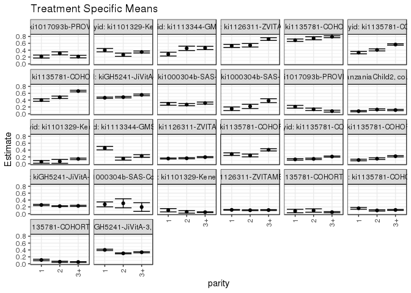

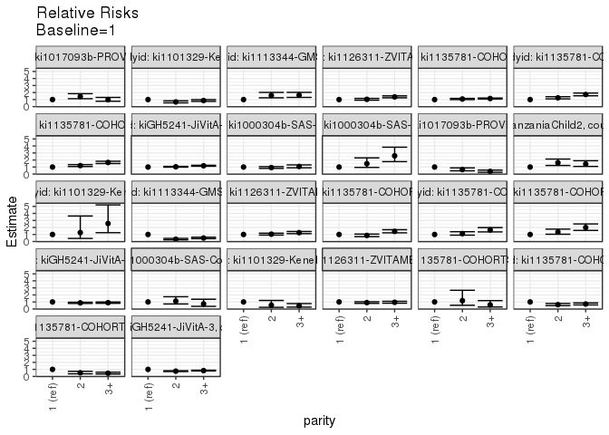

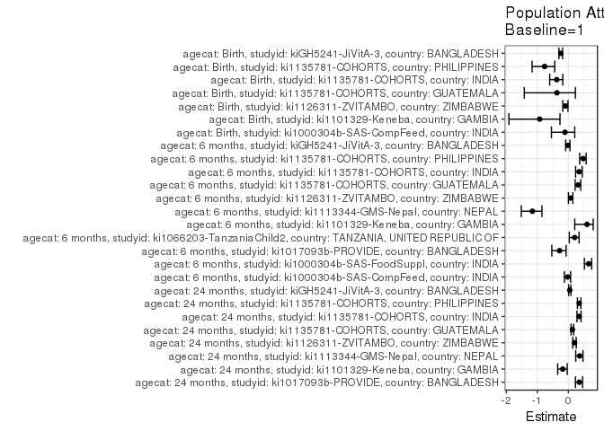

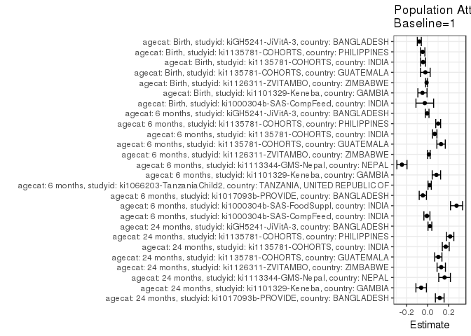

## Results Table

### Parameter: TSM

| agecat | studyid | country | intervention_level | baseline_level | estimate | ci_lower | ci_upper |
| --- | --- | --- | --- | --- | --- | --- | --- |
| Birth | ki1000304b-SAS-CompFeed | INDIA | 1 | NA | 0.2728993 | 0.2015306 | 0.3442680 |
| Birth | ki1000304b-SAS-CompFeed | INDIA | 2 | NA | 0.3043072 | 0.1725462 | 0.4360683 |
| Birth | ki1000304b-SAS-CompFeed | INDIA | 3+ | NA | 0.1958079 | 0.0690292 | 0.3225866 |
| Birth | ki1101329-Keneba | GAMBIA | 1 | NA | 0.1025641 | 0.0549386 | 0.1501896 |
| Birth | ki1101329-Keneba | GAMBIA | 2 | NA | 0.0547945 | 0.0178664 | 0.0917227 |
| Birth | ki1101329-Keneba | GAMBIA | 3+ | NA | 0.0461538 | 0.0337783 | 0.0585294 |
| Birth | ki1126311-ZVITAMBO | ZIMBABWE | 1 | NA | 0.1131930 | 0.1035226 | 0.1228634 |
| Birth | ki1126311-ZVITAMBO | ZIMBABWE | 2 | NA | 0.1026611 | 0.0920136 | 0.1133085 |
| Birth | ki1126311-ZVITAMBO | ZIMBABWE | 3+ | NA | 0.1075901 | 0.0956018 | 0.1195784 |
| Birth | ki1135781-COHORTS | GUATEMALA | 1 | NA | 0.0803571 | 0.0299820 | 0.1307322 |
| Birth | ki1135781-COHORTS | GUATEMALA | 2 | NA | 0.0948905 | 0.0457879 | 0.1439931 |
| Birth | ki1135781-COHORTS | GUATEMALA | 3+ | NA | 0.0464345 | 0.0296294 | 0.0632396 |
| Birth | ki1135781-COHORTS | INDIA | 1 | NA | 0.1584617 | 0.1327250 | 0.1841984 |
| Birth | ki1135781-COHORTS | INDIA | 2 | NA | 0.0971219 | 0.0784525 | 0.1157914 |
| Birth | ki1135781-COHORTS | INDIA | 3+ | NA | 0.1117458 | 0.0988780 | 0.1246137 |
| Birth | ki1135781-COHORTS | PHILIPPINES | 1 | NA | 0.1082756 | 0.0858121 | 0.1307392 |
| Birth | ki1135781-COHORTS | PHILIPPINES | 2 | NA | 0.0561510 | 0.0409927 | 0.0713092 |
| Birth | ki1135781-COHORTS | PHILIPPINES | 3+ | NA | 0.0492166 | 0.0396109 | 0.0588222 |
| Birth | kiGH5241-JiVitA-3 | BANGLADESH | 1 | NA | 0.4023362 | 0.3819835 | 0.4226888 |
| Birth | kiGH5241-JiVitA-3 | BANGLADESH | 2 | NA | 0.3015469 | 0.2873024 | 0.3157914 |
| Birth | kiGH5241-JiVitA-3 | BANGLADESH | 3+ | NA | 0.3325364 | 0.3171511 | 0.3479217 |
| 6 months | ki1000304b-SAS-CompFeed | INDIA | 1 | NA | 0.2910754 | 0.2508203 | 0.3313305 |
| 6 months | ki1000304b-SAS-CompFeed | INDIA | 2 | NA | 0.2685648 | 0.2356071 | 0.3015224 |
| 6 months | ki1000304b-SAS-CompFeed | INDIA | 3+ | NA | 0.3133884 | 0.2836571 | 0.3431198 |
| 6 months | ki1000304b-SAS-FoodSuppl | INDIA | 1 | NA | 0.1475945 | 0.0951125 | 0.2000764 |
| 6 months | ki1000304b-SAS-FoodSuppl | INDIA | 2 | NA | 0.2174397 | 0.1556701 | 0.2792093 |
| 6 months | ki1000304b-SAS-FoodSuppl | INDIA | 3+ | NA | 0.3836129 | 0.3263102 | 0.4409156 |
| 6 months | ki1017093b-PROVIDE | BANGLADESH | 1 | NA | 0.2068902 | 0.1657468 | 0.2480336 |
| 6 months | ki1017093b-PROVIDE | BANGLADESH | 2 | NA | 0.1318022 | 0.0971116 | 0.1664928 |
| 6 months | ki1017093b-PROVIDE | BANGLADESH | 3+ | NA | 0.0788159 | 0.0516963 | 0.1059354 |
| 6 months | ki1066203-TanzaniaChild2 | TANZANIA, UNITED REPUBLIC OF | 1 | NA | 0.0772682 | 0.0600462 | 0.0944903 |
| 6 months | ki1066203-TanzaniaChild2 | TANZANIA, UNITED REPUBLIC OF | 2 | NA | 0.1248867 | 0.1036110 | 0.1461623 |
| 6 months | ki1066203-TanzaniaChild2 | TANZANIA, UNITED REPUBLIC OF | 3+ | NA | 0.1110472 | 0.0923389 | 0.1297556 |
| 6 months | ki1101329-Keneba | GAMBIA | 1 | NA | 0.0559553 | 0.0171072 | 0.0948034 |
| 6 months | ki1101329-Keneba | GAMBIA | 2 | NA | 0.0707572 | 0.0145079 | 0.1270064 |
| 6 months | ki1101329-Keneba | GAMBIA | 3+ | NA | 0.1432193 | 0.1218005 | 0.1646381 |
| 6 months | ki1113344-GMS-Nepal | NEPAL | 1 | NA | 0.4562295 | 0.4051851 | 0.5072740 |
| 6 months | ki1113344-GMS-Nepal | NEPAL | 2 | NA | 0.1495176 | 0.1065991 | 0.1924361 |
| 6 months | ki1113344-GMS-Nepal | NEPAL | 3+ | NA | 0.2271903 | 0.1897189 | 0.2646618 |
| 6 months | ki1126311-ZVITAMBO | ZIMBABWE | 1 | NA | 0.1538071 | 0.1402825 | 0.1673317 |
| 6 months | ki1126311-ZVITAMBO | ZIMBABWE | 2 | NA | 0.1605968 | 0.1456709 | 0.1755228 |
| 6 months | ki1126311-ZVITAMBO | ZIMBABWE | 3+ | NA | 0.1937966 | 0.1774362 | 0.2101570 |
| 6 months | ki1135781-COHORTS | GUATEMALA | 1 | NA | 0.2816311 | 0.2442039 | 0.3190582 |
| 6 months | ki1135781-COHORTS | GUATEMALA | 2 | NA | 0.2428135 | 0.2023658 | 0.2832611 |
| 6 months | ki1135781-COHORTS | GUATEMALA | 3+ | NA | 0.4066173 | 0.3735964 | 0.4396381 |
| 6 months | ki1135781-COHORTS | INDIA | 1 | NA | 0.1279572 | 0.1062977 | 0.1496167 |
| 6 months | ki1135781-COHORTS | INDIA | 2 | NA | 0.1436114 | 0.1235543 | 0.1636685 |
| 6 months | ki1135781-COHORTS | INDIA | 3+ | NA | 0.2108549 | 0.1947687 | 0.2269410 |
| 6 months | ki1135781-COHORTS | PHILIPPINES | 1 | NA | 0.1103808 | 0.0872439 | 0.1335176 |
| 6 months | ki1135781-COHORTS | PHILIPPINES | 2 | NA | 0.1492181 | 0.1243487 | 0.1740875 |
| 6 months | ki1135781-COHORTS | PHILIPPINES | 3+ | NA | 0.2198402 | 0.1996279 | 0.2400525 |
| 6 months | kiGH5241-JiVitA-3 | BANGLADESH | 1 | NA | 0.2557507 | 0.2367982 | 0.2747031 |
| 6 months | kiGH5241-JiVitA-3 | BANGLADESH | 2 | NA | 0.2222139 | 0.2093484 | 0.2350793 |
| 6 months | kiGH5241-JiVitA-3 | BANGLADESH | 3+ | NA | 0.2288047 | 0.2115486 | 0.2460608 |
| 24 months | ki1017093b-PROVIDE | BANGLADESH | 1 | NA | 0.2136443 | 0.1708000 | 0.2564886 |
| 24 months | ki1017093b-PROVIDE | BANGLADESH | 2 | NA | 0.3076903 | 0.2638176 | 0.3515630 |
| 24 months | ki1017093b-PROVIDE | BANGLADESH | 3+ | NA | 0.2135033 | 0.1757523 | 0.2512543 |
| 24 months | ki1101329-Keneba | GAMBIA | 1 | NA | 0.4000971 | 0.3514618 | 0.4487323 |
| 24 months | ki1101329-Keneba | GAMBIA | 2 | NA | 0.2666404 | 0.2189148 | 0.3143660 |
| 24 months | ki1101329-Keneba | GAMBIA | 3+ | NA | 0.3468253 | 0.3191824 | 0.3744682 |
| 24 months | ki1113344-GMS-Nepal | NEPAL | 1 | NA | 0.2850764 | 0.2293144 | 0.3408385 |
| 24 months | ki1113344-GMS-Nepal | NEPAL | 2 | NA | 0.4531707 | 0.3894055 | 0.5169358 |
| 24 months | ki1113344-GMS-Nepal | NEPAL | 3+ | NA | 0.4641811 | 0.4158216 | 0.5125407 |
| 24 months | ki1126311-ZVITAMBO | ZIMBABWE | 1 | NA | 0.5234832 | 0.4786733 | 0.5682931 |
| 24 months | ki1126311-ZVITAMBO | ZIMBABWE | 2 | NA | 0.5421439 | 0.4910556 | 0.5932322 |
| 24 months | ki1126311-ZVITAMBO | ZIMBABWE | 3+ | NA | 0.7233518 | 0.6830020 | 0.7637017 |
| 24 months | ki1135781-COHORTS | GUATEMALA | 1 | NA | 0.6896423 | 0.6547544 | 0.7245302 |
| 24 months | ki1135781-COHORTS | GUATEMALA | 2 | NA | 0.7452267 | 0.7013970 | 0.7890565 |
| 24 months | ki1135781-COHORTS | GUATEMALA | 3+ | NA | 0.7918878 | 0.7644327 | 0.8193430 |
| 24 months | ki1135781-COHORTS | INDIA | 1 | NA | 0.3272012 | 0.2929488 | 0.3614536 |
| 24 months | ki1135781-COHORTS | INDIA | 2 | NA | 0.4076910 | 0.3777137 | 0.4376683 |
| 24 months | ki1135781-COHORTS | INDIA | 3+ | NA | 0.5643219 | 0.5430177 | 0.5856261 |
| 24 months | ki1135781-COHORTS | PHILIPPINES | 1 | NA | 0.4016368 | 0.3645459 | 0.4387277 |
| 24 months | ki1135781-COHORTS | PHILIPPINES | 2 | NA | 0.4817782 | 0.4465538 | 0.5170026 |
| 24 months | ki1135781-COHORTS | PHILIPPINES | 3+ | NA | 0.6629719 | 0.6398381 | 0.6861058 |
| 24 months | kiGH5241-JiVitA-3 | BANGLADESH | 1 | NA | 0.4688423 | 0.4490469 | 0.4886377 |
| 24 months | kiGH5241-JiVitA-3 | BANGLADESH | 2 | NA | 0.4855423 | 0.4646207 | 0.5064640 |
| 24 months | kiGH5241-JiVitA-3 | BANGLADESH | 3+ | NA | 0.5522329 | 0.5298715 | 0.5745942 |

### Parameter: E(Y)

| agecat | studyid | country | intervention_level | baseline_level | estimate | ci_lower | ci_upper |
| --- | --- | --- | --- | --- | --- | --- | --- |
| Birth | ki1000304b-SAS-CompFeed | INDIA | NA | NA | 0.2459893 | 0.1594019 | 0.3325767 |
| Birth | ki1101329-Keneba | GAMBIA | NA | NA | 0.0533049 | 0.0415629 | 0.0650470 |
| Birth | ki1126311-ZVITAMBO | ZIMBABWE | NA | NA | 0.1035505 | 0.0984723 | 0.1086287 |
| Birth | ki1135781-COHORTS | GUATEMALA | NA | NA | 0.0586854 | 0.0428942 | 0.0744767 |
| Birth | ki1135781-COHORTS | INDIA | NA | NA | 0.1152353 | 0.1054865 | 0.1249842 |
| Birth | ki1135781-COHORTS | PHILIPPINES | NA | NA | 0.0613115 | 0.0527962 | 0.0698268 |
| Birth | kiGH5241-JiVitA-3 | BANGLADESH | NA | NA | 0.3232622 | 0.3156056 | 0.3309189 |
| 6 months | ki1000304b-SAS-CompFeed | INDIA | NA | NA | 0.2844311 | 0.2666491 | 0.3022132 |
| 6 months | ki1000304b-SAS-FoodSuppl | INDIA | NA | NA | 0.4235925 | 0.3733796 | 0.4738054 |
| 6 months | ki1017093b-PROVIDE | BANGLADESH | NA | NA | 0.1612350 | 0.1313580 | 0.1911120 |
| 6 months | ki1066203-TanzaniaChild2 | TANZANIA, UNITED REPUBLIC OF | NA | NA | 0.0967419 | 0.0837671 | 0.1097166 |
| 6 months | ki1101329-Keneba | GAMBIA | NA | NA | 0.1398644 | 0.1229849 | 0.1567440 |
| 6 months | ki1113344-GMS-Nepal | NEPAL | NA | NA | 0.2113677 | 0.1776128 | 0.2451225 |
| 6 months | ki1126311-ZVITAMBO | ZIMBABWE | NA | NA | 0.1662648 | 0.1582516 | 0.1742780 |
| 6 months | ki1135781-COHORTS | GUATEMALA | NA | NA | 0.4099896 | 0.3788775 | 0.4411017 |
| 6 months | ki1135781-COHORTS | INDIA | NA | NA | 0.1957586 | 0.1838852 | 0.2076319 |
| 6 months | ki1135781-COHORTS | PHILIPPINES | NA | NA | 0.2112260 | 0.1958496 | 0.2266024 |
| 6 months | kiGH5241-JiVitA-3 | BANGLADESH | NA | NA | 0.2514228 | 0.2432969 | 0.2595487 |
| 24 months | ki1017093b-PROVIDE | BANGLADESH | NA | NA | 0.3292894 | 0.2909105 | 0.3676684 |
| 24 months | ki1101329-Keneba | GAMBIA | NA | NA | 0.3386628 | 0.3136483 | 0.3636773 |
| 24 months | ki1113344-GMS-Nepal | NEPAL | NA | NA | 0.4468938 | 0.4032281 | 0.4905594 |
| 24 months | ki1126311-ZVITAMBO | ZIMBABWE | NA | NA | 0.6535088 | 0.6097853 | 0.6972322 |
| 24 months | ki1135781-COHORTS | GUATEMALA | NA | NA | 0.7919400 | 0.7675726 | 0.8163075 |
| 24 months | ki1135781-COHORTS | INDIA | NA | NA | 0.5001478 | 0.4832966 | 0.5169990 |
| 24 months | ki1135781-COHORTS | PHILIPPINES | NA | NA | 0.6167689 | 0.5974942 | 0.6360437 |
| 24 months | kiGH5241-JiVitA-3 | BANGLADESH | NA | NA | 0.4908193 | 0.4776993 | 0.5039392 |

### Parameter: RR

| agecat | studyid | country | intervention_level | baseline_level | estimate | ci_lower | ci_upper |
| --- | --- | --- | --- | --- | --- | --- | --- |
| Birth | ki1000304b-SAS-CompFeed | INDIA | 1 | 1 | 1.0000000 | 1.0000000 | 1.0000000 |
| Birth | ki1000304b-SAS-CompFeed | INDIA | 2 | 1 | 1.1150897 | 0.7146424 | 1.7399263 |
| Birth | ki1000304b-SAS-CompFeed | INDIA | 3+ | 1 | 0.7175098 | 0.3718804 | 1.3843706 |
| Birth | ki1101329-Keneba | GAMBIA | 1 | 1 | 1.0000000 | 1.0000000 | 1.0000000 |
| Birth | ki1101329-Keneba | GAMBIA | 2 | 1 | 0.5342466 | 0.2356709 | 1.2110933 |
| Birth | ki1101329-Keneba | GAMBIA | 3+ | 1 | 0.4500000 | 0.2632335 | 0.7692791 |
| Birth | ki1126311-ZVITAMBO | ZIMBABWE | 1 | 1 | 1.0000000 | 1.0000000 | 1.0000000 |
| Birth | ki1126311-ZVITAMBO | ZIMBABWE | 2 | 1 | 0.9069559 | 0.7930593 | 1.0372099 |
| Birth | ki1126311-ZVITAMBO | ZIMBABWE | 3+ | 1 | 0.9505011 | 0.8261336 | 1.0935910 |
| Birth | ki1135781-COHORTS | GUATEMALA | 1 | 1 | 1.0000000 | 1.0000000 | 1.0000000 |
| Birth | ki1135781-COHORTS | GUATEMALA | 2 | 1 | 1.1808597 | 0.5238079 | 2.6621012 |
| Birth | ki1135781-COHORTS | GUATEMALA | 3+ | 1 | 0.5778515 | 0.2801877 | 1.1917454 |
| Birth | ki1135781-COHORTS | INDIA | 1 | 1 | 1.0000000 | 1.0000000 | 1.0000000 |
| Birth | ki1135781-COHORTS | INDIA | 2 | 1 | 0.6129051 | 0.4766654 | 0.7880845 |
| Birth | ki1135781-COHORTS | INDIA | 3+ | 1 | 0.7051916 | 0.5780453 | 0.8603048 |
| Birth | ki1135781-COHORTS | PHILIPPINES | 1 | 1 | 1.0000000 | 1.0000000 | 1.0000000 |
| Birth | ki1135781-COHORTS | PHILIPPINES | 2 | 1 | 0.5185928 | 0.3693183 | 0.7282024 |
| Birth | ki1135781-COHORTS | PHILIPPINES | 3+ | 1 | 0.4545488 | 0.3428698 | 0.6026036 |
| Birth | kiGH5241-JiVitA-3 | BANGLADESH | 1 | 1 | 1.0000000 | 1.0000000 | 1.0000000 |
| Birth | kiGH5241-JiVitA-3 | BANGLADESH | 2 | 1 | 0.7494900 | 0.6999580 | 0.8025270 |
| Birth | kiGH5241-JiVitA-3 | BANGLADESH | 3+ | 1 | 0.8265138 | 0.7730263 | 0.8837023 |
| 6 months | ki1000304b-SAS-CompFeed | INDIA | 1 | 1 | 1.0000000 | 1.0000000 | 1.0000000 |
| 6 months | ki1000304b-SAS-CompFeed | INDIA | 2 | 1 | 0.9226638 | 0.8020952 | 1.0613560 |
| 6 months | ki1000304b-SAS-CompFeed | INDIA | 3+ | 1 | 1.0766571 | 0.8906953 | 1.3014444 |
| 6 months | ki1000304b-SAS-FoodSuppl | INDIA | 1 | 1 | 1.0000000 | 1.0000000 | 1.0000000 |
| 6 months | ki1000304b-SAS-FoodSuppl | INDIA | 2 | 1 | 1.4732241 | 0.9419378 | 2.3041746 |
| 6 months | ki1000304b-SAS-FoodSuppl | INDIA | 3+ | 1 | 2.5991011 | 1.7665376 | 3.8240491 |
| 6 months | ki1017093b-PROVIDE | BANGLADESH | 1 | 1 | 1.0000000 | 1.0000000 | 1.0000000 |
| 6 months | ki1017093b-PROVIDE | BANGLADESH | 2 | 1 | 0.6370634 | 0.4606796 | 0.8809806 |
| 6 months | ki1017093b-PROVIDE | BANGLADESH | 3+ | 1 | 0.3809550 | 0.2574543 | 0.5636989 |
| 6 months | ki1066203-TanzaniaChild2 | TANZANIA, UNITED REPUBLIC OF | 1 | 1 | 1.0000000 | 1.0000000 | 1.0000000 |
| 6 months | ki1066203-TanzaniaChild2 | TANZANIA, UNITED REPUBLIC OF | 2 | 1 | 1.6162745 | 1.2225497 | 2.1367992 |
| 6 months | ki1066203-TanzaniaChild2 | TANZANIA, UNITED REPUBLIC OF | 3+ | 1 | 1.4371651 | 1.0886039 | 1.8973326 |
| 6 months | ki1101329-Keneba | GAMBIA | 1 | 1 | 1.0000000 | 1.0000000 | 1.0000000 |
| 6 months | ki1101329-Keneba | GAMBIA | 2 | 1 | 1.2645291 | 0.4401396 | 3.6330149 |
| 6 months | ki1101329-Keneba | GAMBIA | 3+ | 1 | 2.5595292 | 1.2575987 | 5.2092850 |
| 6 months | ki1113344-GMS-Nepal | NEPAL | 1 | 1 | 1.0000000 | 1.0000000 | 1.0000000 |
| 6 months | ki1113344-GMS-Nepal | NEPAL | 2 | 1 | 0.3277246 | 0.2402389 | 0.4470691 |
| 6 months | ki1113344-GMS-Nepal | NEPAL | 3+ | 1 | 0.4979737 | 0.4078398 | 0.6080275 |
| 6 months | ki1126311-ZVITAMBO | ZIMBABWE | 1 | 1 | 1.0000000 | 1.0000000 | 1.0000000 |
| 6 months | ki1126311-ZVITAMBO | ZIMBABWE | 2 | 1 | 1.0441445 | 0.9192886 | 1.1859582 |
| 6 months | ki1126311-ZVITAMBO | ZIMBABWE | 3+ | 1 | 1.2599980 | 1.1160402 | 1.4225248 |
| 6 months | ki1135781-COHORTS | GUATEMALA | 1 | 1 | 1.0000000 | 1.0000000 | 1.0000000 |
| 6 months | ki1135781-COHORTS | GUATEMALA | 2 | 1 | 0.8621686 | 0.7012516 | 1.0600114 |
| 6 months | ki1135781-COHORTS | GUATEMALA | 3+ | 1 | 1.4437940 | 1.2396628 | 1.6815388 |
| 6 months | ki1135781-COHORTS | INDIA | 1 | 1 | 1.0000000 | 1.0000000 | 1.0000000 |
| 6 months | ki1135781-COHORTS | INDIA | 2 | 1 | 1.1223393 | 0.9025048 | 1.3957217 |
| 6 months | ki1135781-COHORTS | INDIA | 3+ | 1 | 1.6478546 | 1.3695976 | 1.9826443 |
| 6 months | ki1135781-COHORTS | PHILIPPINES | 1 | 1 | 1.0000000 | 1.0000000 | 1.0000000 |
| 6 months | ki1135781-COHORTS | PHILIPPINES | 2 | 1 | 1.3518487 | 1.0365191 | 1.7631079 |
| 6 months | ki1135781-COHORTS | PHILIPPINES | 3+ | 1 | 1.9916533 | 1.5848197 | 2.5029239 |
| 6 months | kiGH5241-JiVitA-3 | BANGLADESH | 1 | 1 | 1.0000000 | 1.0000000 | 1.0000000 |
| 6 months | kiGH5241-JiVitA-3 | BANGLADESH | 2 | 1 | 0.8688693 | 0.7910291 | 0.9543693 |
| 6 months | kiGH5241-JiVitA-3 | BANGLADESH | 3+ | 1 | 0.8946398 | 0.8090511 | 0.9892829 |
| 24 months | ki1017093b-PROVIDE | BANGLADESH | 1 | 1 | 1.0000000 | 1.0000000 | 1.0000000 |
| 24 months | ki1017093b-PROVIDE | BANGLADESH | 2 | 1 | 1.4401991 | 1.1282501 | 1.8383988 |
| 24 months | ki1017093b-PROVIDE | BANGLADESH | 3+ | 1 | 0.9993400 | 0.7637833 | 1.3075442 |
| 24 months | ki1101329-Keneba | GAMBIA | 1 | 1 | 1.0000000 | 1.0000000 | 1.0000000 |
| 24 months | ki1101329-Keneba | GAMBIA | 2 | 1 | 0.6664393 | 0.5375052 | 0.8263013 |
| 24 months | ki1101329-Keneba | GAMBIA | 3+ | 1 | 0.8668530 | 0.7512294 | 1.0002724 |
| 24 months | ki1113344-GMS-Nepal | NEPAL | 1 | 1 | 1.0000000 | 1.0000000 | 1.0000000 |
| 24 months | ki1113344-GMS-Nepal | NEPAL | 2 | 1 | 1.5896462 | 1.2519151 | 2.0184876 |
| 24 months | ki1113344-GMS-Nepal | NEPAL | 3+ | 1 | 1.6282691 | 1.3065335 | 2.0292325 |
| 24 months | ki1126311-ZVITAMBO | ZIMBABWE | 1 | 1 | 1.0000000 | 1.0000000 | 1.0000000 |
| 24 months | ki1126311-ZVITAMBO | ZIMBABWE | 2 | 1 | 1.0356472 | 0.9160885 | 1.1708096 |
| 24 months | ki1126311-ZVITAMBO | ZIMBABWE | 3+ | 1 | 1.3818053 | 1.2513078 | 1.5259122 |
| 24 months | ki1135781-COHORTS | GUATEMALA | 1 | 1 | 1.0000000 | 1.0000000 | 1.0000000 |
| 24 months | ki1135781-COHORTS | GUATEMALA | 2 | 1 | 1.0805989 | 1.0017097 | 1.1657011 |
| 24 months | ki1135781-COHORTS | GUATEMALA | 3+ | 1 | 1.1482588 | 1.0822147 | 1.2183334 |
| 24 months | ki1135781-COHORTS | INDIA | 1 | 1 | 1.0000000 | 1.0000000 | 1.0000000 |
| 24 months | ki1135781-COHORTS | INDIA | 2 | 1 | 1.2459948 | 1.0985356 | 1.4132478 |
| 24 months | ki1135781-COHORTS | INDIA | 3+ | 1 | 1.7246940 | 1.5448475 | 1.9254778 |
| 24 months | ki1135781-COHORTS | PHILIPPINES | 1 | 1 | 1.0000000 | 1.0000000 | 1.0000000 |
| 24 months | ki1135781-COHORTS | PHILIPPINES | 2 | 1 | 1.1995370 | 1.0694621 | 1.3454324 |
| 24 months | ki1135781-COHORTS | PHILIPPINES | 3+ | 1 | 1.6506752 | 1.4970446 | 1.8200717 |
| 24 months | kiGH5241-JiVitA-3 | BANGLADESH | 1 | 1 | 1.0000000 | 1.0000000 | 1.0000000 |
| 24 months | kiGH5241-JiVitA-3 | BANGLADESH | 2 | 1 | 1.0356196 | 0.9775397 | 1.0971504 |
| 24 months | kiGH5241-JiVitA-3 | BANGLADESH | 3+ | 1 | 1.1778649 | 1.1135529 | 1.2458911 |

### Parameter: PAR

| agecat | studyid | country | intervention_level | baseline_level | estimate | ci_lower | ci_upper |
| --- | --- | --- | --- | --- | --- | --- | --- |
| Birth | ki1000304b-SAS-CompFeed | INDIA | 1 | NA | -0.0269100 | -0.1111384 | 0.0573183 |
| Birth | ki1101329-Keneba | GAMBIA | 1 | NA | -0.0492592 | -0.0928837 | -0.0056347 |
| Birth | ki1126311-ZVITAMBO | ZIMBABWE | 1 | NA | -0.0096425 | -0.0181550 | -0.0011300 |
| Birth | ki1135781-COHORTS | GUATEMALA | 1 | NA | -0.0216717 | -0.0677134 | 0.0243700 |
| Birth | ki1135781-COHORTS | INDIA | 1 | NA | -0.0432263 | -0.0670285 | -0.0194242 |
| Birth | ki1135781-COHORTS | PHILIPPINES | 1 | NA | -0.0469642 | -0.0679933 | -0.0259350 |
| Birth | kiGH5241-JiVitA-3 | BANGLADESH | 1 | NA | -0.0790739 | -0.0981180 | -0.0600299 |
| 6 months | ki1000304b-SAS-CompFeed | INDIA | 1 | NA | -0.0066443 | -0.0354261 | 0.0221375 |
| 6 months | ki1000304b-SAS-FoodSuppl | INDIA | 1 | NA | 0.2759980 | 0.2184122 | 0.3335839 |
| 6 months | ki1017093b-PROVIDE | BANGLADESH | 1 | NA | -0.0456552 | -0.0800386 | -0.0112719 |
| 6 months | ki1066203-TanzaniaChild2 | TANZANIA, UNITED REPUBLIC OF | 1 | NA | 0.0194736 | 0.0038630 | 0.0350842 |
| 6 months | ki1101329-Keneba | GAMBIA | 1 | NA | 0.0839091 | 0.0438706 | 0.1239476 |
| 6 months | ki1113344-GMS-Nepal | NEPAL | 1 | NA | -0.2448619 | -0.2932193 | -0.1965045 |
| 6 months | ki1126311-ZVITAMBO | ZIMBABWE | 1 | NA | 0.0124577 | 0.0005144 | 0.0244010 |
| 6 months | ki1135781-COHORTS | GUATEMALA | 1 | NA | 0.1283585 | 0.0882407 | 0.1684763 |
| 6 months | ki1135781-COHORTS | INDIA | 1 | NA | 0.0678014 | 0.0467838 | 0.0888190 |
| 6 months | ki1135781-COHORTS | PHILIPPINES | 1 | NA | 0.1008452 | 0.0776940 | 0.1239965 |
| 6 months | kiGH5241-JiVitA-3 | BANGLADESH | 1 | NA | -0.0043279 | -0.0218299 | 0.0131741 |
| 24 months | ki1017093b-PROVIDE | BANGLADESH | 1 | NA | 0.1156452 | 0.0741058 | 0.1571845 |
| 24 months | ki1101329-Keneba | GAMBIA | 1 | NA | -0.0614343 | -0.1115587 | -0.0113098 |
| 24 months | ki1113344-GMS-Nepal | NEPAL | 1 | NA | 0.1618174 | 0.1063136 | 0.2173212 |
| 24 months | ki1126311-ZVITAMBO | ZIMBABWE | 1 | NA | 0.1300256 | 0.0901457 | 0.1699055 |
| 24 months | ki1135781-COHORTS | GUATEMALA | 1 | NA | 0.1022977 | 0.0679341 | 0.1366613 |
| 24 months | ki1135781-COHORTS | INDIA | 1 | NA | 0.1729466 | 0.1400485 | 0.2058448 |
| 24 months | ki1135781-COHORTS | PHILIPPINES | 1 | NA | 0.2151321 | 0.1802077 | 0.2500565 |
| 24 months | kiGH5241-JiVitA-3 | BANGLADESH | 1 | NA | 0.0219770 | 0.0037616 | 0.0401924 |

### Parameter: PAF

| agecat | studyid | country | intervention_level | baseline_level | estimate | ci_lower | ci_upper |
| --- | --- | --- | --- | --- | --- | --- | --- |
| Birth | ki1000304b-SAS-CompFeed | INDIA | 1 | NA | -0.1093951 | -0.5466720 | 0.2042543 |
| Birth | ki1101329-Keneba | GAMBIA | 1 | NA | -0.9241025 | -1.9135260 | -0.2706839 |
| Birth | ki1126311-ZVITAMBO | ZIMBABWE | 1 | NA | -0.0931189 | -0.1789009 | -0.0135787 |
| Birth | ki1135781-COHORTS | GUATEMALA | 1 | NA | -0.3692857 | -1.4191803 | 0.2249675 |
| Birth | ki1135781-COHORTS | INDIA | 1 | NA | -0.3751135 | -0.6007421 | -0.1812878 |
| Birth | ki1135781-COHORTS | PHILIPPINES | 1 | NA | -0.7659929 | -1.1677299 | -0.4387084 |
| Birth | kiGH5241-JiVitA-3 | BANGLADESH | 1 | NA | -0.2446124 | -0.3053855 | -0.1866686 |
| 6 months | ki1000304b-SAS-CompFeed | INDIA | 1 | NA | -0.0233600 | -0.1289824 | 0.0723809 |
| 6 months | ki1000304b-SAS-FoodSuppl | INDIA | 1 | NA | 0.6515650 | 0.5151563 | 0.7495957 |
| 6 months | ki1017093b-PROVIDE | BANGLADESH | 1 | NA | -0.2831595 | -0.5337328 | -0.0735236 |
| 6 months | ki1066203-TanzaniaChild2 | TANZANIA, UNITED REPUBLIC OF | 1 | NA | 0.2012946 | 0.0292199 | 0.3428683 |
| 6 months | ki1101329-Keneba | GAMBIA | 1 | NA | 0.5999317 | 0.2046515 | 0.7987616 |
| 6 months | ki1113344-GMS-Nepal | NEPAL | 1 | NA | -1.1584641 | -1.5155326 | -0.8520799 |
| 6 months | ki1126311-ZVITAMBO | ZIMBABWE | 1 | NA | 0.0749269 | 0.0006221 | 0.1437071 |
| 6 months | ki1135781-COHORTS | GUATEMALA | 1 | NA | 0.3130775 | 0.2178839 | 0.3966848 |
| 6 months | ki1135781-COHORTS | INDIA | 1 | NA | 0.3463520 | 0.2329132 | 0.4430151 |
| 6 months | ki1135781-COHORTS | PHILIPPINES | 1 | NA | 0.4774282 | 0.3631345 | 0.5712104 |
| 6 months | kiGH5241-JiVitA-3 | BANGLADESH | 1 | NA | -0.0172135 | -0.0892925 | 0.0500960 |
| 24 months | ki1017093b-PROVIDE | BANGLADESH | 1 | NA | 0.3511961 | 0.2256349 | 0.4563979 |
| 24 months | ki1101329-Keneba | GAMBIA | 1 | NA | -0.1814025 | -0.3443751 | -0.0381863 |
| 24 months | ki1113344-GMS-Nepal | NEPAL | 1 | NA | 0.3620936 | 0.2358295 | 0.4674950 |
| 24 months | ki1126311-ZVITAMBO | ZIMBABWE | 1 | NA | 0.1989653 | 0.1403037 | 0.2536242 |
| 24 months | ki1135781-COHORTS | GUATEMALA | 1 | NA | 0.1291735 | 0.0858973 | 0.1704010 |
| 24 months | ki1135781-COHORTS | INDIA | 1 | NA | 0.3457911 | 0.2777033 | 0.4074605 |
| 24 months | ki1135781-COHORTS | PHILIPPINES | 1 | NA | 0.3488050 | 0.2904085 | 0.4023957 |
| 24 months | kiGH5241-JiVitA-3 | BANGLADESH | 1 | NA | 0.0447761 | 0.0072062 | 0.0809243 |